# Part2

It will plot based on plot_ function that created before, where the datasets is combined_condtions, with colors = colors_cus_10 and it's based on index 0 to 4, where it represents each year from 2000 to 2004 colors respectively, it will plot the maximum of coefficient each year, on the certain x and y coordinate (e.g in 2000, it's (0.3, 0.2) coordinate. While it will also put the label of the minimum of coefficient each year.

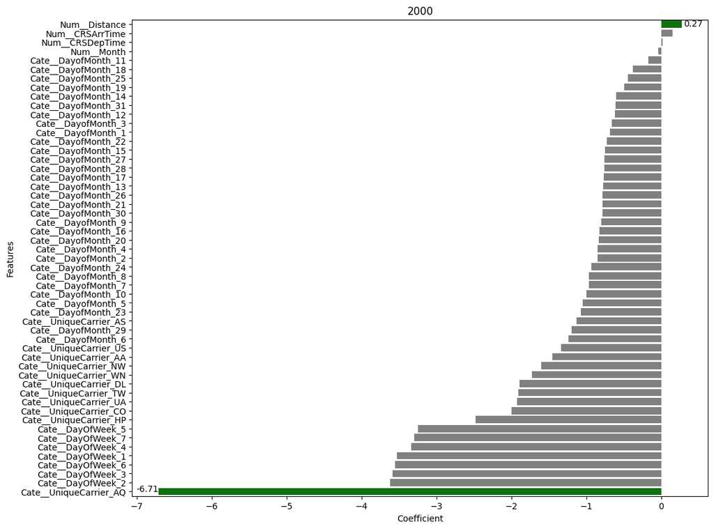

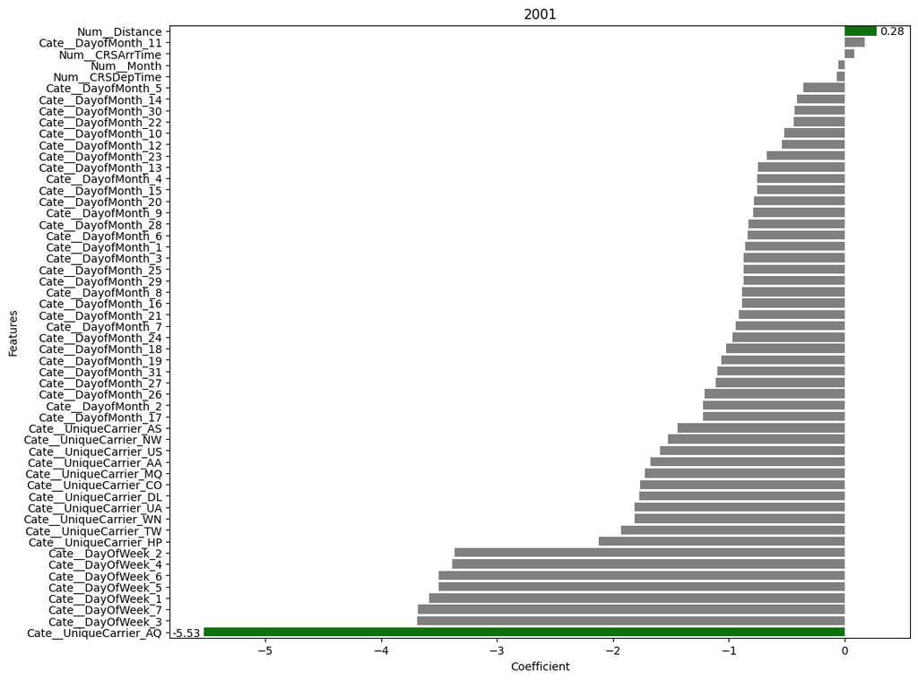

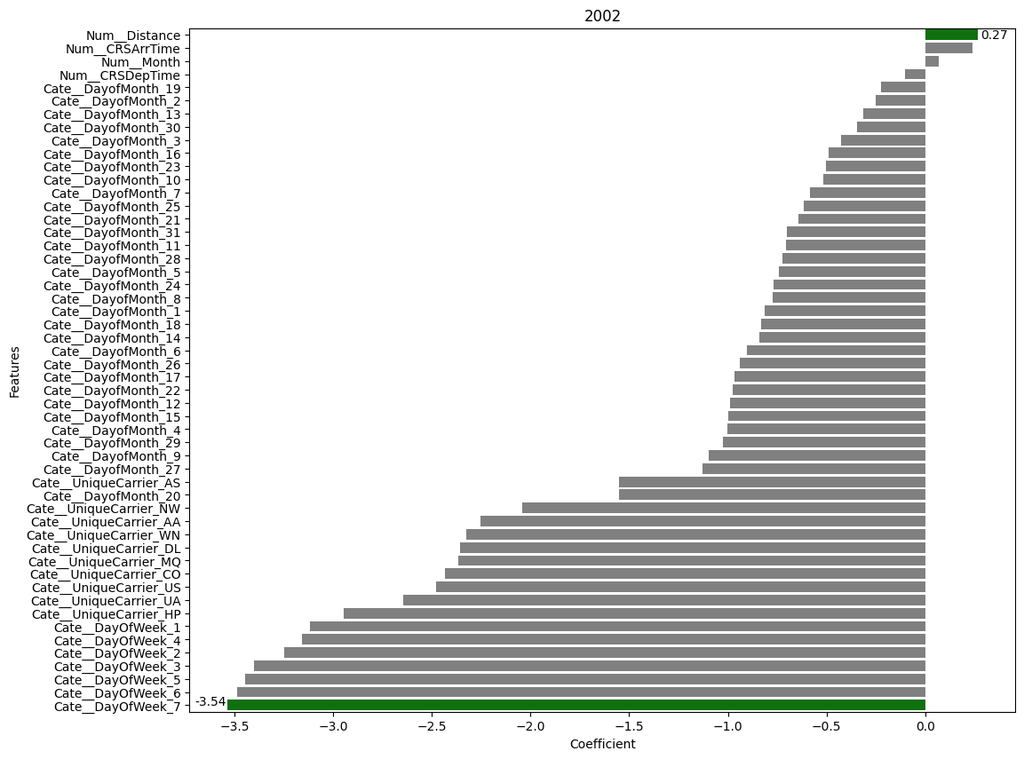

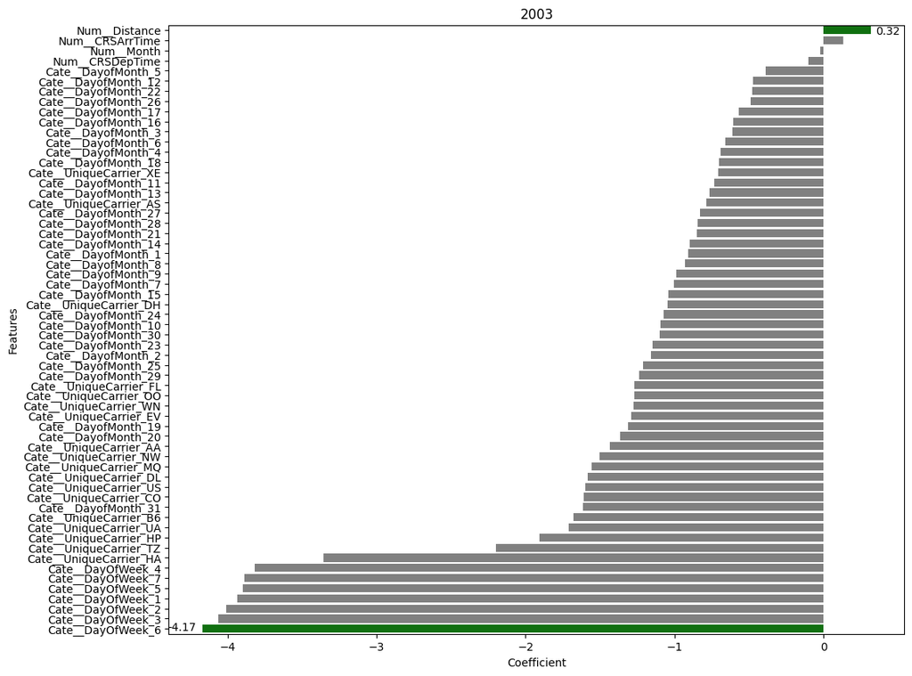

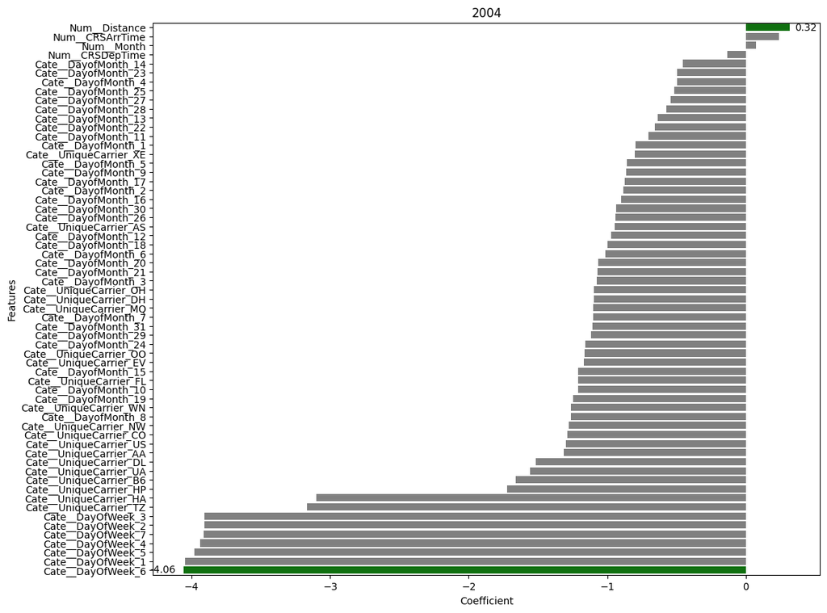

```python
plot_(combined_conditions, colours_cus_10[0],2000,0.3,0.2,round(maxi_10[0],2),-7,52,round(mini_10[0],2))
plot_(combined_conditions, colours_cus_10[1],2001,0.3,0.3,round(maxi_10[1],2),-5.8,53.4,round(mini_10[1],2))
plot_(combined_conditions, colours_cus_10[2],2002,0.28,0.3,round(maxi_10[2],2),-3.7,51,round(mini_10[2],2))
plot_(combined_conditions, colours_cus_10[3],2003,0.35,0.4,round(maxi_10[3],2),-4.4,59.2,round(mini_10[3],2))
plot_(combined_conditions, colours_cus_10[4],2004,0.35,0.35,round(maxi_10[4],2),-4.3,60.2,round(mini_10[4],2))
```

It will plot the barplot by each year, in each column and rows based on the ax. It will created 2 rows, 3 columns. Then the ax will be flatten into 1d, for easier visualisation. Then it will plot x axis as Coefficient and y axis as Selected_Feature. The data used will be combined_conditions with when the Years is equal to certain year, e.g 2000, 2000, etc. Then it will be plot based on ax index from 0 to 4. It then set the title based on specific year, then it will set y label as Features and set x label as Coefficient

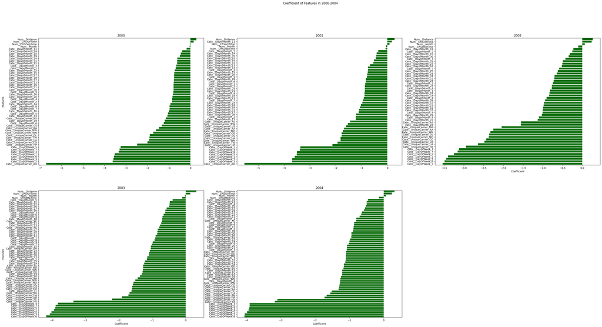

```python
fig, ax =plt.subplots(2,3,figsize= (40,20))
ax=ax.flatten()
sns.barplot(y= 'Selected_Feature', x='Coefficient', data= combined_conditions[combined_conditions['Years']==2000],color="green", ax=ax[0])
ax[0].set_title("2000")
ax[0].set_ylabel("Features")
ax[0].set_xlabel("")
sns.barplot(y= 'Selected_Feature', x='Coefficient', data= combined_conditions[combined_conditions['Years']==2001],color="green", ax=ax[1])
ax[1].set_title("2001")
ax[1].set_ylabel("")
ax[1].set_xlabel("")
sns.barplot(y= 'Selected_Feature', x='Coefficient', data= combined_conditions[combined_conditions['Years']==2002],color="green", ax=ax[2])
ax[2].set_title("2002")
ax[2].set_ylabel("")
ax[2].set_xlabel("Coefficient")
sns.barplot(y= 'Selected_Feature', x='Coefficient', data= combined_conditions[combined_conditions['Years']==2003],color="green", ax=ax[3])
ax[3].set_title("2003")
ax[3].set_ylabel("Features")
ax[3].set_xlabel("Coefficient")
sns.barplot(y= 'Selected_Feature', x='Coefficient', data= combined_conditions[combined_conditions['Years']==2004],color="green", ax=ax[4])
ax[4].set_title("2004")
ax[4].set_ylabel("")
ax[4].set_xlabel("Coefficient")
ax[5].axis('off')
plt.suptitle('Coefficient of Features in 2000-2004')
plt.show()
```

```python
#it will contains only feature which is Num__Distance, Selected_Feature, Num_CRSArrTime, Num_CRSDepTime
less_features = combined_conditions[(combined_conditions['Selected_Feature'] == 'Num__Distance')|(combined_conditions['Selected_Feature'] == 'Num__CRSArrTime')|(combined_conditions['Selected_Feature'] == 'Num__CRSDepTime')]
```

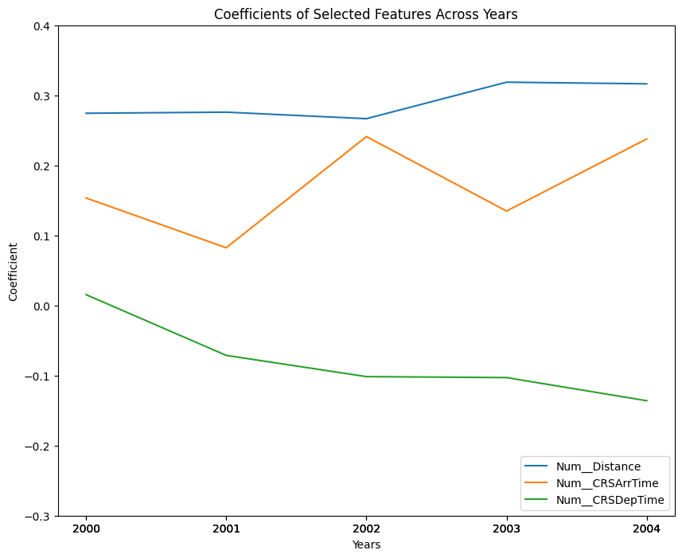

```python
#it will plot the data which is less_features, with x axis is Years, y axis is coefficient and it will be colored based on Selected_Feature
plt.subplots(figsize= (10,8))
sns.lineplot(data= less_features, x= 'Years', y = 'Coefficient', hue= 'Selected_Feature')
plt.ylim(-0.3, 0.4) #it will set the y limit -0.3 to 0.4, so that the legend later won't cover the line graph
plt.title("Coefficients of Selected Features Across Years")
plt.legend(loc="lower right") # the legend will be put on the bottom right
plt.xticks(less_features['Years'])#so that the x will be in discrete and based on Years
plt.show()
```

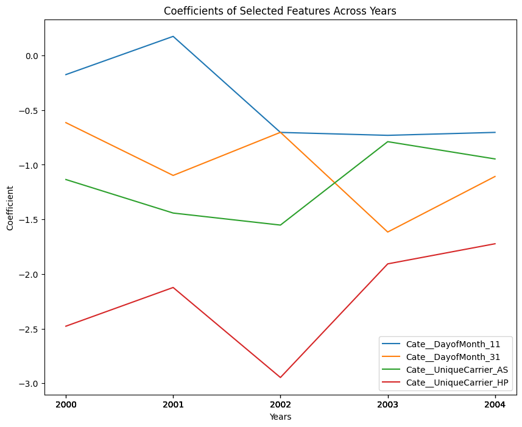

```python
#it will contains only feature which is Cate__DayofMonth_31, Selected_Feature, Cate__DayofMonth_11, Cate__UniqueCarrier_AS,Cate__UniqueCarrier_HP.
# it's following the R markdown, which is DayofMonth is 31 and 11. Also the Unique Carrier when it's AS and HP
#UniqueCarrier AQ might have high coefficient but only available in 2000 to 2001

more_features = combined_conditions[(combined_conditions['Selected_Feature'] == 'Cate__DayofMonth_31')|(combined_conditions['Selected_Feature'] == 'Cate__DayofMonth_11')|(combined_conditions['Selected_Feature'] == 'Cate__UniqueCarrier_AS')|(combined_conditions['Selected_Feature'] == 'Cate__UniqueCarrier_HP')]

#it will plot the data which is more_features, with x axis is Years, y axis is coefficient and it will be colored based on Selected_Feature
plt.subplots(figsize= (10,8))
sns.lineplot(data= more_features, x= 'Years', y = 'Coefficient', hue= 'Selected_Feature')
plt.title("Coefficients of Selected Features Across Years")
plt.legend(loc="lower right") # the legend will be put on the bottom right
plt.xticks(more_features['Years'])#so that the x will be in discrete and based on Years
plt.show()
```